# naloga1-Nagelj

12 May 2019

# UVOD

V nalogi preverjamo razlicne lasnosti linearne regresije. Zato ustvarimo umetne podatke s katerimi bomo eksperimentiral. Najprej bomo ocenili parametre in preverili njihovo točnost, nato pa bomo testirali kaj se zgodi v primeru skaliranja in standariziranja podatkov.

# PODATKI

Podatke definiramo kot v nalogi in sicer po enačbi
$$y = 7 + 5X_2 + 10X_3 - 4X_4 + \epsilon$$
. Podatki so definirani na različnih skalah in sicer.
$$X_2 = [10000, 60000]; X_3 = [10, 35]; X_4 = [0, 1]$$
. Vsebinsko, te predstavljajo število čebel, temperaturo in vlažnost. Definiramo populacijo velikost 10000 iz katere bomo kasneje pridobili naše vzorce. Vrednost $y$ definiramo po zgornji enačbi pri čemer je
$$\epsilon \sim{Normal(0, 100)}$$
.

# OCENJEVANJE PARAMETROV Z VEČKRATNIM VZORČENJEM

Testirali bomo ocene parametrov na različnih skalah v odvisnosti od števila vzorcev in velikosti vzorcev. Prav tako si bomo ob fiksiranju enega pogledali konvergenco ocen v odvisnosti od drugega.

## Podatki na nespremenjenih skalah

### Ocenjevanje parametrov regresije

Ogledali si bomo omejen nabor kombinacij in sicer pri številu vzorcev in velikostih vzorcev 10, 50 in 100.

Primer rezultata simulacij:

```r
head(sim)
```

```
##    sampleSize nSubset subset       X_i1     X_i2      X_i3       X_i4
## 1:         10      10      1  -1.798288 4.999960 10.291755   2.703299
## 2:         10      10      2  23.279096 5.000071  9.610047 -15.973909
## 3:         10      10      3 -47.849409 5.000478 11.747801   1.884175
## 4:         10      10      4  20.920789 5.000498  8.707469  -9.720463
## 5:         10      10      5  20.566780 4.999660 10.155986 -20.652627
## 6:         10      10      6  21.155167 5.000329  9.320916 -15.846604
```

Ogladamo si prikaze regresijskih premic. Saj imamo opravka z multiplo regresijo prikažemo vpliv posamezne neodvisne spremenljivke, ko upoštevamo povprečne napovedi drugih dveh. Opazimo, da so zaradi velikih vrednosti $X_2$ vse regresijske premice tako blizu, da zgleda da je praktično samo ena. S tem, manjšamo skalo x-ov (relativno na y) vidimo vse večjo razpršenost in netočnost regresijskih premic.

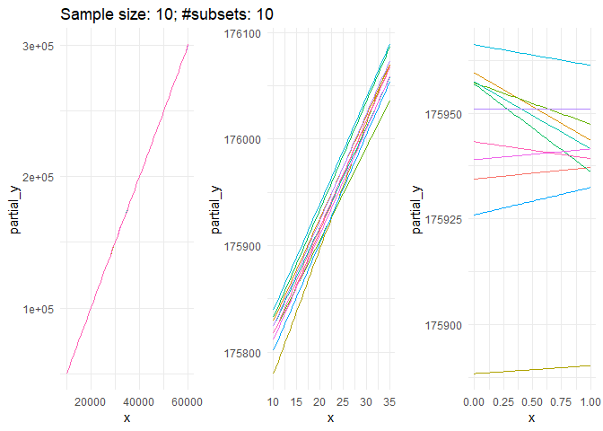

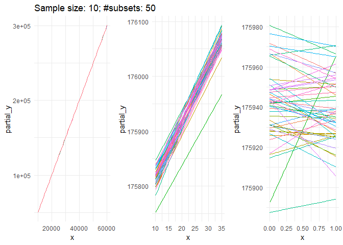

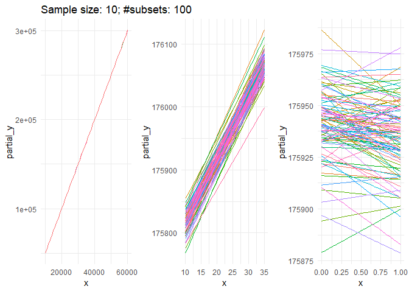

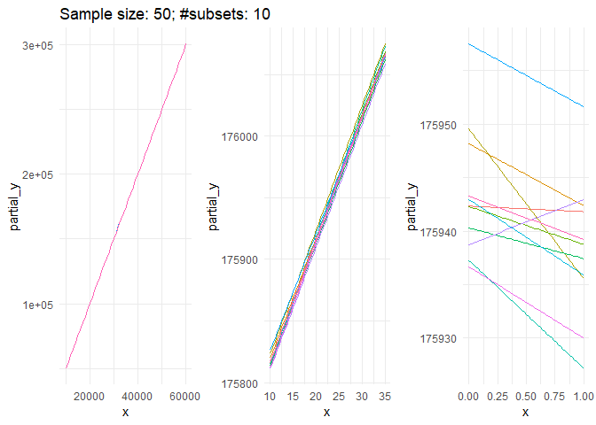

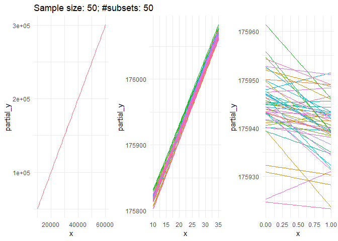

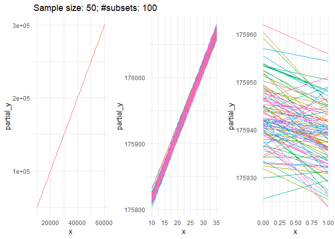

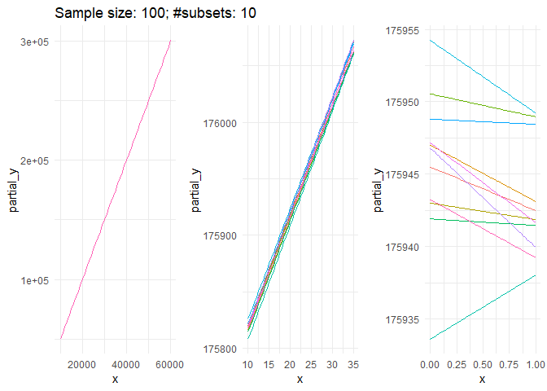

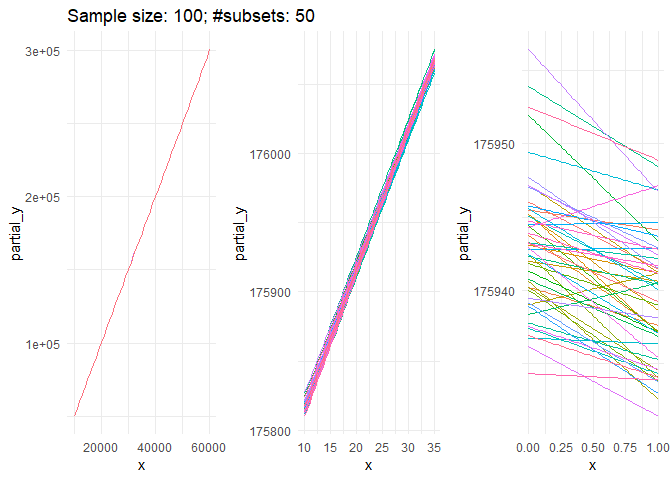

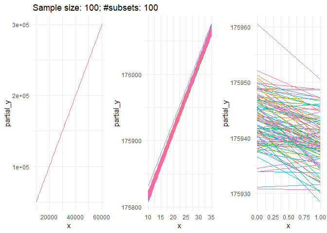

### Konvergenca

Zanima nas kako hitro se z zgoraj navedeno metodo približujemo pravi vrednosti regresijskih koeficinetov. Pojav opazujemo ob fiksiranju bodisi števila vzorcev ali velikosti vzorcev glede na vrednosti drugega. V splošnem pri obeh spodnjih grafih konvergence opazimo, da IZ sicer pokrivajo pravo vrednost, vendar so te pri neodvisnih spremenljivkah na manjših skalah precej širši v primerjavi s tistimi, ki so definirani na večji skali.

#### Fiksna velikost vzorca

Za velikost vzorca smo vzeli velikost 50. Opazimo, da IZ pravo vrednost pokrije že v 10 vzorcih. Razlike v napakah ocen parametrov pa so glede na razpon neodvisnih spremenljivk kot pričakovano precej različne. V primeru $X_2$ so napake praktično zanemarljive, že na začetku, med tem ko so v primeru $X_4$, ki je definiran med 0 in 1 razlike v povprečnih ocenah precej večje (tudi en velikostni razred prave).

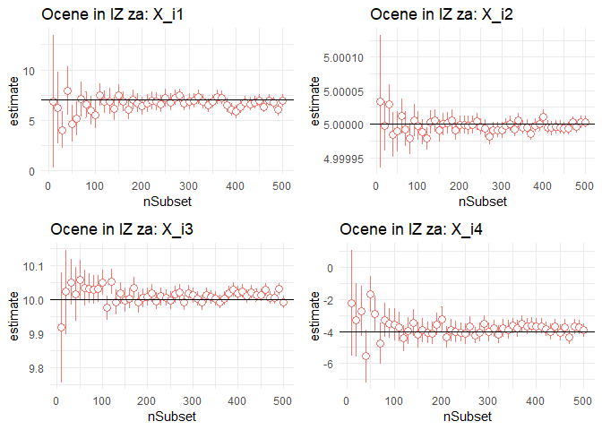

#### Fiksno število vzorcev (subsetov)

Za število vzorcev smo vzeli velikost 50. Opazimo, da IZ pravo vrednost pokrije že v 10 vzorcih. Za razliko od zgornjega grafa so povprečja veliko bolj stabilna in bližje pravim, vrednostim z večanjem velikosti vzorca. Vidimo torej, da dobimo boljše ocene hitreje z večanjem velikosti vzorca kot števila vzorcev.

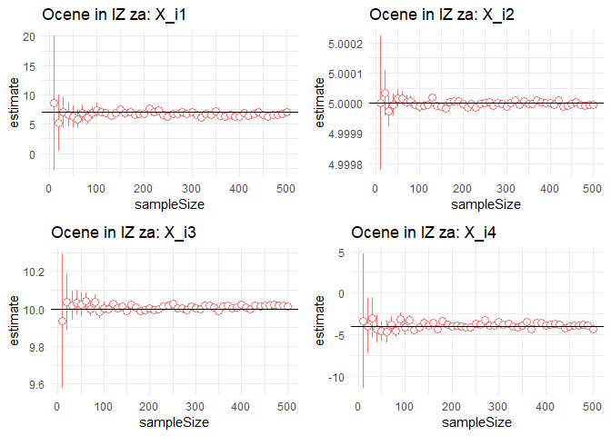

### Delež pravih parametrov v IZ

Za različne velikosti vzorca in število vzorcev pogledamo kolikokrat se parameter pod katerim smo generirali podatke res nahaja v IZ. Torej sedaj nas ponovno kot v zgornjem primeru zanima kakovost ocene in ali je naše zaupanje v njih uporavičeno. To naredimo na enak način kot pri konvergenci, torej ob fiksiranju posameznih parametrov našega vzorca. Iz spodnje tabele je razvidno, da je v obeh primerih, bodisi pri majhni velikosti vzorca ali majhnem številu vzorcev naš 95% IZ preozek in zajema populacijski vrednost v manj kot 95% primerih. To nas ne preseneti, saj je tak izračun IZ asimptotski. Razlik glede na skale neodvisnih spremenljiv ni.

```
##     sampleSize nSubset  X_i1  X_i2  X_i3  X_i4
##  1:         10     500 0.906 0.892 0.912 0.894
##  2:         50     500 0.960 0.944 0.956 0.954
##  3:        100     500 0.946 0.936 0.948 0.946
##  4:        200     500 0.956 0.954 0.948 0.932
##  5:        500      10 1.000 0.900 0.900 0.900
##  6:        500      50 0.920 0.940 0.980 0.940
##  7:        500     100 0.940 0.910 0.940 0.980
##  8:        500     200 0.940 0.945 0.970 0.965
##  9:        500     500 0.932 0.950 0.916 0.956
## 10:        500    1000 0.940 0.951 0.948 0.958
## 11:       1000     500 0.948 0.948 0.956 0.960
```

## Podatki na spremenjenih skalah

Kakovost modela si bomo ogledali še vprimeru minmax sklaliranje in standardizacije. Za to bomo primerjali RMSE modelov z različnimi skalami. Naš vzorec bo naključen žreb velikost 30. Normalnost odvisne spremenljivke je seveda ohranjena.

Dobimo enake vrednosti RMSE, torej linearne kombinacije podatkov in koficientov se pri spremenjenih skalah podatkov ne razlikujejo.

```
## [1] "NONE"
## [1] "rmse:"
## [1] 11.13616
## [1] "#######"
```

```
## [1] "MINMAX"
## [1] "rmse:"
## [1] 11.13616
## [1] "#######"
```

```
## [1] "STD"
## [1] "rmse:"
## [1] 11.13616
## [1] "#######"
```

### Konvergenca

Pogledamo še konvergenco na standardiziranih podatkih. S standarizacijo se seveda zgoraj napisane lasnosti ne spremenijo. Spremeni se le skala parametrov in napak, katero je nekoliko lažje interpretirali.

#### Fiksna velikost vzorca

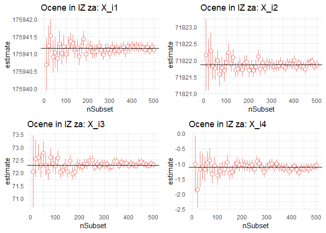

#### Fiksno število vzorcev (subsetov)

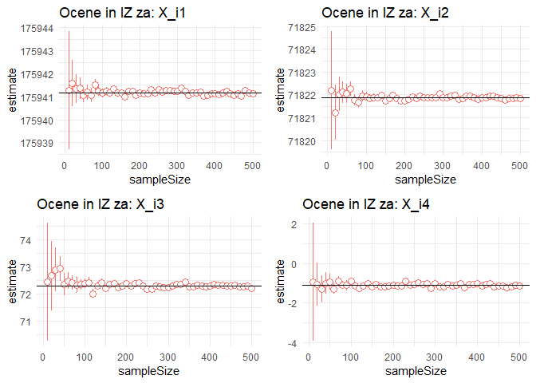

### Ocenjevanje parametrov z različnimi metodami

V tem poglavju sledi še primerjava ocen parametrov pribljena z različnimi algoritmi. Primerjava je izvedena na istem podatkovnem setu kot v zgornjem poglavju, torej žreb vzorca velikega 30 enot. Primerjali bomo metodo OLS in dve numerični metodi, gradientni spust in genetski algoritem.

Te metode so pogojene na hiperparametre, kot so learning rate, število iteracij, velikost populacije itd. V spodnjih slikah vidimo, da z gradientnem spustu v našem primeru pri 100 iteracija in standariziranih podatkih dosežemo boljše rezultate kot z genetskim algoritmom in enake kot z ols. Pri minmax sklairanih podatkih pa je najboljši ols, za tem genetski algoritem in nato gradientni spust. Z dovolj velikim številom iteracij bi v tem primeru zagotovo prišli do enakih ocen parametrov. V splošnem moramo pri optimizacijskih metodah biti previdini, saj lahko zaidejo v lokalni minimum, zato je pri gradientnem spustu potrebno algoritem zagnati večkrat, pri genetskih algoritmih pa uporabiti mutacije.

#### Minmax skaliranje

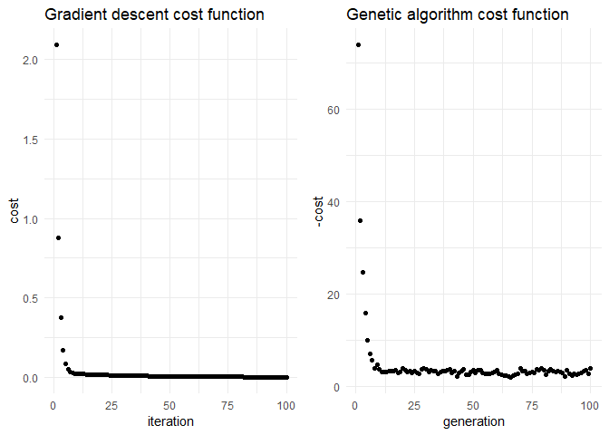

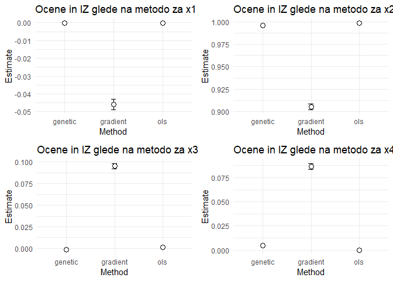

```
##      ols.RMSE    gd.RMSE     ga.RMSE
## 1 3.98723e-05 0.04631131 0.001804176
```

#### Standarizacija

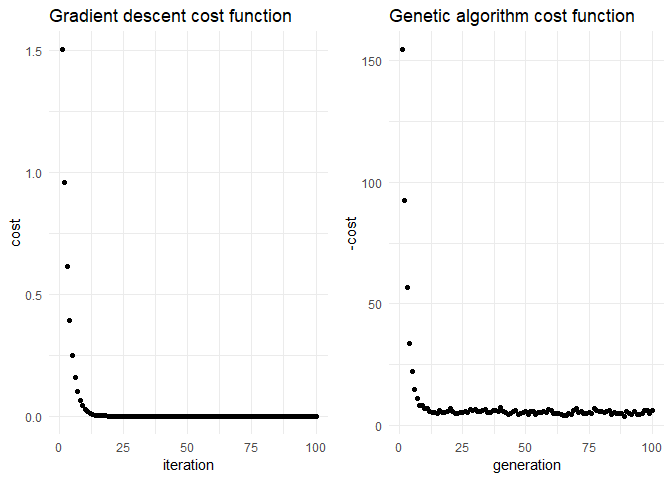

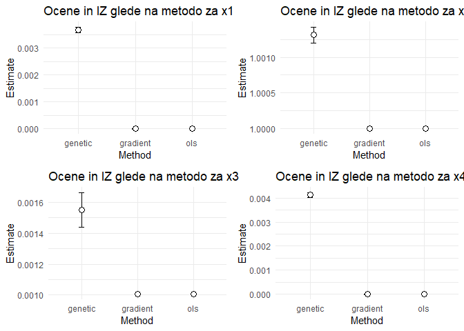

```
##       ols.RMSE      gd.RMSE     ga.RMSE
## 1 0.0001388825 0.0001388825 0.005704797
```

# ZAKLJUČEK

Iz prvega dela domače naloge smo videli, da bomo z večanjem bodisi velikosti vzorca ali števila vzorcev strmeli h boljši oceni parametrov. Ugotovili smo tudi, da bomo hitreje dobili boljše ocene z večjanjem velikosti vzorca. Opazili smo tudi, da so ocene neodvisnih spremenljivk na manjši skali slabše in imajo večjo standardno napako. Intervali zaupanja v primeru bodisi premajhne velikosti vzorca ali števila vzorcev preozek (asimptotski IZ). Nato smo videli, da spreminjanje skale bodisi s standarizacijo ali skaliranjem nima vpliva. Enako velja za npr. logistično regresijo in odločitvena drevesa. Kljub temu si s tem lahko pomagamo pri vizualizaciji parametrov na isti skali in določanju velikosti učinka posameznih regresorjev. Standarizacija je vseeno ključnega pomena pri optimizaciji, saj pomaga pri konvergenci algoritmov.